# Biometry / Homework 2 / Auriel Fournier / March 8, 2014

# One Way Anova on Stream Type for Early Summer

```r
Early = fish[fish$SEASNUM == "6", ]

early <- lm(V72 ~ STREAMTYPE, data = Early)
```

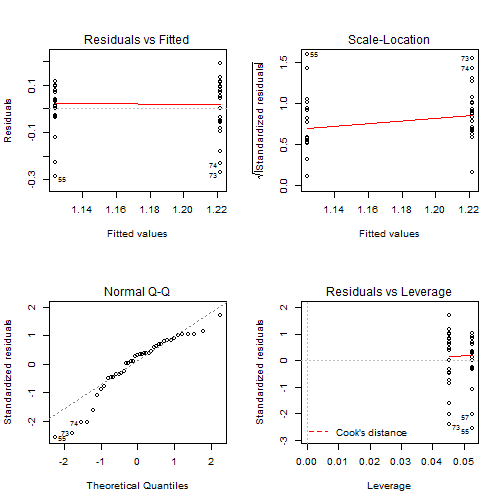

```r
layout(matrix(c(1, 2, 3, 4), 2, 2))
plot(early)
```

### Figure 31 - Output graphs from One Way ANOVA on Stream Type during Early Summer

```r
png(filename = "OneANOVAEarly.png")
layout(matrix(c(1, 2, 3, 4), 2, 2))
plot(early)
dev.off()
```

Code to generate table

```r
# sjt.df(anova(early), alternateRowColors=TRUE, no.output=TRUE,
# describe=FALSE)$knitr
```

### Table 10 - Output from One Way ANOVA on Stream Type during Early Summer

| Variable | Df | Sum Sq | Mean Sq | F value | Pr(>F) |
| --- | --- | --- | --- | --- | --- |
| STREAMTYPE | 1 | 0.0971225548385395 | 0.0971225548385395 | 7.3657171993248 | 0.00984761176081986 |
| Residuals | 39 | 0.514244510914736 | 0.0131857566901214 | NA | NA |

## Residual Plot

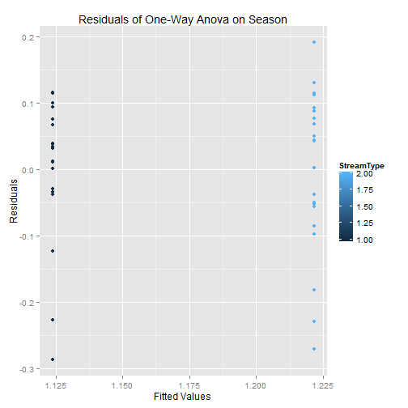

```r
early.df <- data.frame(M1_Fit = seq(0, 0, length = 41), M1_Resid = seq(0, 0,
    length = 41), Season = seq(0, 0, length = 41))

early.resid = resid(early)
early.fitted = fitted(early)

early.df$M1_Fit = early.fitted
early.df$M1_Resid = early.resid
early.df$StreamType = Early$STREAMTYPE

ggplot(early.df, aes(M1_Fit, M1_Resid, colour = StreamType)) + geom_point() +
    xlab("Fitted Values") + ylab("Residuals") + ggtitle("Residuals of One-Way Anova on Season")
```

### Figure 32 - Residual Plot from One Way ANOVA on Stream Type during Early Summer

```r
png(filename = "OneANOVASeasonResidualEarly.png")
ggplot(early.df, aes(M1_Fit, M1_Resid, colour = StreamType)) + geom_point() +
    xlab("Fitted Values") + ylab("Residuals") + ggtitle("Residuals of One-Way Anova on Season")

dev.off()
```

## Interaction Plot

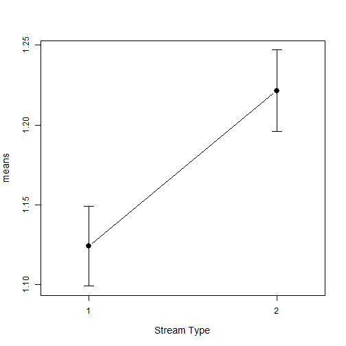

```r
lineplot.CI(STREAMTYPE, V72, data = Early, cex = 1.5, xlab = "Stream Type",
    ylab = "means", cex.lab = 1.2, x.leg = 1, pch = c(16, 16))
```

### Figure 33 - Interaction Plot from One Way ANOVA on Stream Type during Early Summer

```r
png(filename = "OneANOVASeasonInteractionEarly.png")
lineplot.CI(STREAMTYPE, V72, data = Early, cex = 1.5, xlab = "Stream Type",
    ylab = "means", cex.lab = 1.2, x.leg = 1, pch = c(16, 16))
dev.off()
```

# One Way Anova on Stream Type for Late Summer

```r
Late = fish[fish$SEASNUM == "8", ]

late <- lm(V72 ~ STREAMTYPE, data = Late)
```

```
## hat values (leverages) are all = 0.05263
##  and there are no factor predictors; no plot no. 5
```

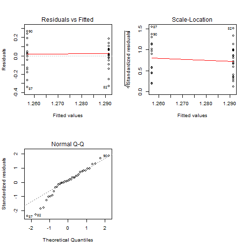

```r
layout(matrix(c(1, 2, 3, 4), 2, 2))
plot(late)
```

### Figure 34 - Output Graphs from One Way ANOVA on Stream Type in Late Summer

```r
png(filename = "OneANOVALate.png")
layout(matrix(c(1, 2, 3, 4), 2, 2))
plot(late)
```

```
## hat values (leverages) are all = 0.05263
##  and there are no factor predictors; no plot no. 5
```

```r
dev.off()
```

Code to generate table

```r
# sjt.df(anova(late), alternateRowColors=TRUE, no.output=TRUE,
# describe=FALSE)$knitr
```

### Table 11 - Output from One Way ANOVA on Stream Type in Late Summer

| Variable | Df | Sum Sq | Mean Sq | F value | Pr(>F) |
| --- | --- | --- | --- | --- | --- |
| STREAMTYPE | 1 | 0.0111442452083829 | 0.0111442452083829 | 0.513669437925617 | 0.47817895508213 |
| Residuals | 36 | 0.781033088365048 | 0.0216953635656958 | NA | NA |

## Residual Plot

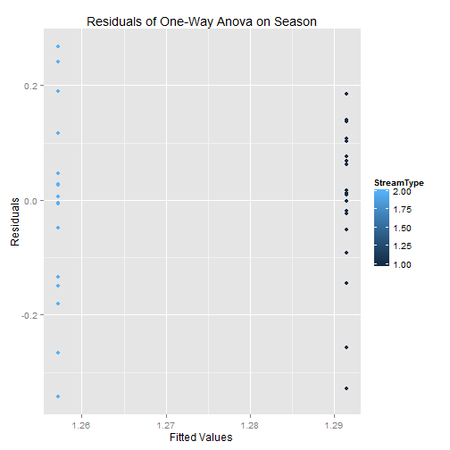

```r
late.df <- data.frame(M1_Fit = seq(0, 0, length = 38), M1_Resid = seq(0, 0,
    length = 38), Season = seq(0, 0, length = 38))

late.resid = resid(late)
late.fitted = fitted(late)

late.df$M1_Fit = late.fitted
late.df$M1_Resid = late.resid
late.df$StreamType = Late$STREAMTYPE

ggplot(late.df, aes(M1_Fit, M1_Resid, colour = StreamType)) + geom_point() +
    xlab("Fitted Values") + ylab("Residuals") + ggtitle("Residuals of One-Way Anova on Season")
```

### Figure 35 - Residuals Plot from One Way ANOVA on Stream Type in Late Summer

```r
png(filename = "OneANOVASeasonResidualLate.png")
ggplot(late.df, aes(M1_Fit, M1_Resid, colour = StreamType)) + geom_point() +
    xlab("Fitted Values") + ylab("Residuals") + ggtitle("Residuals of One-Way Anova on Season")

dev.off()
```

## Interaction Plot

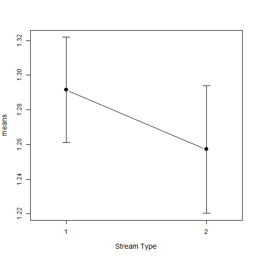

```r
lineplot.CI(STREAMTYPE, V72, data = Late, cex = 1.5, xlab = "Stream Type", ylab = "means",
    cex.lab = 1.2, x.leg = 1, pch = c(16, 16))
```

### Figure 36 - Interaction Plot from One Way ANOVA on Stream Type in Late Summer

```r
png(filename = "OneANOVASeasonInteractionLate.png")
lineplot.CI(STREAMTYPE, V72, data = Late, cex = 1.5, xlab = "Stream Type", ylab = "means",
    cex.lab = 1.2, x.leg = 1, pch = c(16, 16))
dev.off()
```

# One Way Anova on Stream Type for Fall

```r
Fall = fish[fish$SEASNUM == "10", ]

fall <- lm(V72 ~ STREAMTYPE, data = Fall)
```

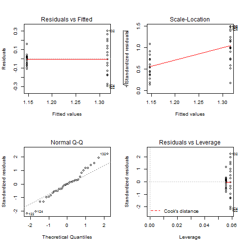

```r
layout(matrix(c(1, 2, 3, 4), 2, 2))
plot(fall)
```

### Figure 37 - Output graphs from One Way Anova on Stream Type during the Fall

```r
png(filename = "OneANOVAFall.png")
layout(matrix(c(1, 2, 3, 4), 2, 2))
plot(fall)
dev.off()
```

Code to generate table

```r
# sjt.df(anova(fall), alternateRowColors=TRUE, no.output=TRUE,
# describe=FALSE)$knitr
```

### Table 12 - Results of One Way ANOVA on Stream Type during the Fall

| Variable | Df | Sum Sq | Mean Sq | F value | Pr(>F) |
| --- | --- | --- | --- | --- | --- |
| STREAMTYPE | 1 | 0.250284629128181 | 0.250284629128181 | 12.9444129335494 | 0.00103668148792724 |
| Residuals | 33 | 0.638066230089374 | 0.0193353403057386 | NA | NA |

## Residual Plot

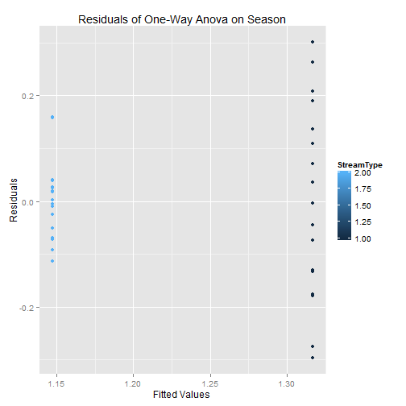

```r
fall.df <- data.frame(M1_Fit = seq(0, 0, length = 35), M1_Resid = seq(0, 0,
    length = 35), StreamType = seq(0, 0, length = 35))

fall.resid = resid(fall)
fall.fitted = fitted(fall)

fall.df$M1_Fit = fall.fitted
fall.df$M1_Resid = fall.resid
fall.df$StreamType = Fall$STREAMTYPE

ggplot(fall.df, aes(M1_Fit, M1_Resid, colour = StreamType)) + geom_point() +
    xlab("Fitted Values") + ylab("Residuals") + ggtitle("Residuals of One-Way Anova on Season")
```

### Figure 38 - Residuals from One Way ANOVA on Stream Type during the Fall

```r
png(filename = "OneANOVASeasonResidualFall.png")
ggplot(fall.df, aes(M1_Fit, M1_Resid, colour = StreamType)) + geom_point() +
    xlab("Fitted Values") + ylab("Residuals") + ggtitle("Residuals of One-Way Anova on Season")

dev.off()
```

## Interaction Plot

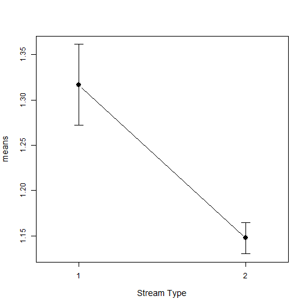

```r
lineplot.CI(STREAMTYPE, V72, data = Fall, cex = 1.5, xlab = "Stream Type", ylab = "means",
    cex.lab = 1.2, x.leg = 1, pch = c(16, 16))
```

### Figure 39 - Interaction Plot on One Way Anova on Stream Type during the Fall

```r
png(filename = "OneANOVASeasonInteractionFall.png")
lineplot.CI(STREAMTYPE, V72, data = Fall, cex = 1.5, xlab = "Stream Type", ylab = "means",
    cex.lab = 1.2, x.leg = 1, pch = c(16, 16))
dev.off()
```